# CMSC320: 0101: Final Project

### Final Insights:

**NOTE: My RF model stopped working randomly so I was forced to use only a simple linear models, however, a RandomForest can help with accurate predictions and better test and training data.**

#### **EXTRA IDEAS:**

- You can build a coefficient plot using the package **coefplot**
- You can have more fun with this package and learn about it [here](https://cran.r-project.org/web/packages/coefplot/coefplot.pdf)
- For example, to show the relationship between the median house value and a few of the other attributes.

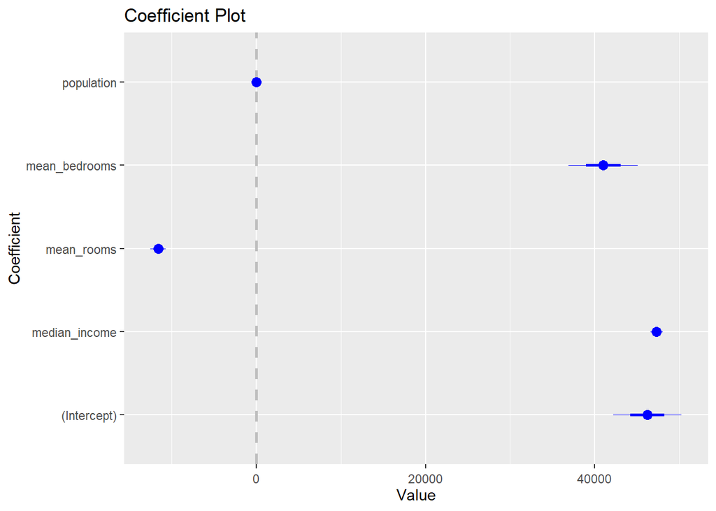

```r
library(coefplot)
data(housing)
model1 <- lm(housing$median_house_value~median_income+mean_rooms+mean_bedrooms+population, data=housing)
coefplot(model1)
```

- One can proceed similarly with the idea of predicting which kind of proximity to the ocean is most desirable. Here of course, we are limited by the fact that desirability and popularity of the housing location is denoted by the price/ median value of the unit.

```r
house_ocean= glm(housing_final$median_house_value~housing_final$INLAND+housing_final$ISLAND+housing_final$NEAR_BAY+housing_final$NEAR_OCEAN+housing_final$OCEAN_1H)
error = cv.glm(housing_final , house_ocean, K=5)
error$delta
```

```
## [1] 16786610242 16786610242
```

```r
rmse = sqrt(error$delta)[1]
rmse
```

```
## [1] 129563.2
```

```r
#Now we check the linear coefficients of the equation
house_ocean$coefficients
```

```
##              (Intercept)     housing_final$INLAND     housing_final$ISLAND
##               240084.285              -115278.893               140355.715
##   housing_final$NEAR_BAY housing_final$NEAR_OCEAN   housing_final$OCEAN_1H
##                19128.026                 9349.692                       NA
```

### Acknowledgements:

This data was initially featured in the following paper: Pace, R. Kelley, and Ronald Barry. “Sparse spatial autoregressions.” Statistics & Probability Letters 33.3 (1997): 291-297.

### References:

- Housing Dataset from Kaggle: https://www.kaggle.com/camnugent/california-housing-prices/downloads/california-housing-prices.zip/1
- R Documentation: https://www.rdocumentation.org/
- Extra help for R: https://cran.r-project.org/
- Color codes from https://www.color-hex.com/
- CMSC320 Lecture Notes: http://www.hcbravo.org/IntroDataSci/bookdown-notes/
- California Land Popularity, Image: https://www.quora.com/Was-California-always-a-popular-state
- Missing Data in R:https://medium.com/coinmonks/dealing-with-missing-data-using-r-3ae428da2d17
- Using ggplot: http://r-statistics.co/Top50-Ggplot2-Visualizations-MasterList-R-Code.html